# Final Project

Biostatistics (BIOL_SCI 337-0)

Author

Skyler Stone

Published

June 3, 2024

**GitHub Repo Link**

biostats-final.git

## Exploratory Data Analysis

```r
data_display <- ggplot(diversity, aes(x = SpeciesRichness, fill = as.factor(ManagementStage))) +
  geom_histogram(position = "stack", binwidth = 1, color = 'black') +
  labs(
    title = "Stacked Histograms of SpeciesRichness by Management Stage",
    x = "Species Richness",
    y = "Count",
    fill = "Management Stage"
  ) +
  theme_minimal()
```

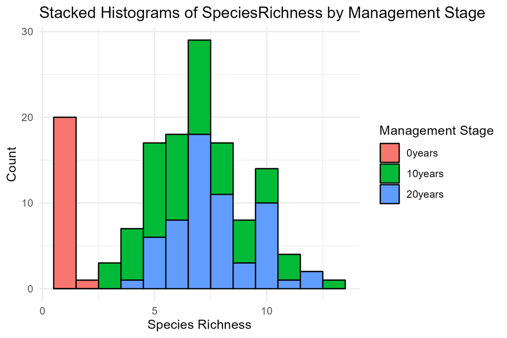

Display of Species Richness for the three Management Stages

###### Data Description

Unmanaged Areas (0 years): Typically, lower species richness due to invasive species like buckthorn dominating.

Early-Stage Management (10 years): An intermediate increase in species richness as invasive species are removed and native species are reintroduced.

Late-Stage Management (20 years): Highest species richness, reflecting successful restoration with sustained management efforts.

## Describing the data, with uncertainty

```r
# Calculate descriptive statistics
descriptive_stats <- diversity %>%
  group_by(ManagementStage) %>%
  summarise(
    mean = mean(SpeciesRichness),
    sd = sd(SpeciesRichness),
    cv = sd / mean,
    se = sd / sqrt(n())
  )

kable(descriptive_stats, caption = "Descriptive Statistics")
```

Descriptive Statistics

| ManagementStage | mean | sd | cv | se |
| --- | --- | --- | --- | --- |
| 0years | 1.047619 | 0.2182179 | 0.2082989 | 0.0476190 |
| 10years | 6.733333 | 2.2464033 | 0.3336242 | 0.2900094 |
| 20years | 7.633333 | 1.8223348 | 0.2387338 | 0.2352624 |

###### 95% confidence intervals of `SpeciesRichness` for each `ManagementStage`

```r
ci <- diversity %>%
  group_by(ManagementStage) %>%
  summarise(
    mean = mean(SpeciesRichness),
    se = sd(SpeciesRichness) / sqrt(n()),
    lower_ci = mean - qt(0.975, df = n() - 1) * se,
    upper_ci = mean + qt(0.975, df = n() - 1) * se
  )

ci_table <- kable(ci)

ci_table
```

| ManagementStage | mean | se | lower_ci | upper_ci |
| --- | --- | --- | --- | --- |
| 0years | 1.047619 | 0.0476190 | 0.9482875 | 1.146951 |
| 10years | 6.733333 | 0.2900094 | 6.1530258 | 7.313641 |
| 20years | 7.633333 | 0.2352624 | 7.1625743 | 8.104092 |

## Comparing two means

**Null Hypothesis:** The biodiversity of buckthorn thickets is no different from the biodiversity of buckthorn thickets after continued restoration over time.

###### Two-sample Welch’s t-test

```r
# Hypothesis Testing ----
# Subset data for 10years and 20years
data_10years <- diversity %>%
  filter(ManagementStage == "10years")

data_20years <- diversity %>%
  filter(ManagementStage == "20years")

# Perform two-sample t-test
t_test <- t.test(data_10years$SpeciesRichness, data_20years$SpeciesRichness, var.equal = FALSE)

# Create a data frame for the results
results <- data.frame(
  Statistic = c("t-value", "Degrees of Freedom (df)", "P-value", "95% Confidence Interval", "Mean of 10years (x)", "Mean of 20years (y)"),
  Value = c("-2.4101", "113.19", "0.01756", "(-1.6398293, -0.1601707)", "6.733333", "7.633333")
)

# Generate the HTML table
html_table <- kable(results, format = "html", table.attr = "style='width:50%;'", caption = "Welch Two Sample t-test Results")

# Print the HTML table
html_table
```

Welch Two Sample t-test Results

| Statistic | Value |
| --- | --- |
| t-value | -2.4101 |
| Degrees of Freedom (df) | 113.19 |
| P-value | 0.01756 |
| 95% Confidence Interval | (-1.6398293, -0.1601707) |
| Mean of 10years (x) | 6.733333 |
| Mean of 20years (y) | 7.633333 |

## Handling Violations of Assumptions

**Violations:** 1. Data are normally distributed within each group 2. The variances of the two groups are equal (homogeneity of variance)

**Transformation:** Most of the data is not normally distributed, so therefore either a log transformation, a square root transformation, or a Box-Cox transformation may make the data more normal.

**Assumptions of a Mann-Whitney U-test:** 1. two samples are independent 2. observations are ordinal (e.g. they can be ranked)

**The data does meet the assumptions for a Mann-Whitney U-test**

```r
wilcox_test <- wilcox.test(data_10years$SpeciesRichness, data_20years$SpeciesRichness)

# Extracting W and P-value
W <- wilcox_test$statistic
p_value <- wilcox_test$p.value

# Print W and P-value
cat("Mann-Whitney U-test (Wilcoxon rank sum test) results:\n")
```

```
Mann-Whitney U-test (Wilcoxon rank sum test) results:
```

```r
cat("W:", W, "\n")
```

```
W: 1320
```

```r
cat("P-value:", p_value, "\n")
```

```
P-value: 0.01079987
```

The P-value is less than the significance level of 0.05, and therefore, indicates that there is a statistically significant difference between `SpeciesRichness` of the 10years and 20years `ManagementStages`.

## ANOVA (analysis of variance)

```r
# Perform ANOVA
anova_results <- aov(SpeciesRichness ~ as.factor(ManagementStage), data = diversity)
summary(anova_results)
```

```
                            Df Sum Sq Mean Sq F value Pr(>F)
as.factor(ManagementStage)   2  697.1   348.6   97.25 <2e-16 ***
Residuals                  138  494.6     3.6
---
Signif. codes:  0 '***' 0.001 '**' 0.01 '*' 0.05 '.' 0.1 ' ' 1
```

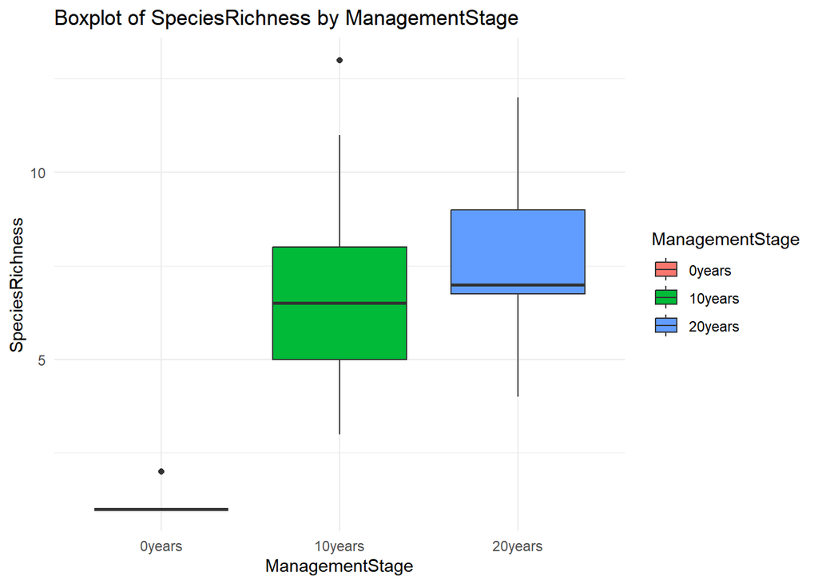

```r
ggplot(diversity, aes(x = ManagementStage, y = SpeciesRichness, fill = ManagementStage)) +
  geom_boxplot() +
  theme_minimal() +
  labs(title = "Boxplot of SpeciesRichness by ManagementStage",
       x = "ManagementStage",
       y = "SpeciesRichness")
```

```r
# Perform Tukey HSD test
tukey_results <- TukeyHSD(anova_results)

print(tukey_results)
```

```
  Tukey multiple comparisons of means
    95% family-wise confidence level

Fit: aov(formula = SpeciesRichness ~ as.factor(ManagementStage), data = diversity)

$`as.factor(ManagementStage)`
                    diff       lwr      upr     p adj
10years-0years  5.685714 4.5484325 6.822996 0.0000000
20years-0years  6.585714 5.4484325 7.722996 0.0000000
20years-10years 0.900000 0.0810635 1.718937 0.0274506
```

```r
# Perform Kruskal-Wallis test
kruskal_test <- kruskal.test(SpeciesRichness ~ as.factor(ManagementStage), data = diversity)

print(kruskal_test)
```

```
    Kruskal-Wallis rank sum test

data:  SpeciesRichness by as.factor(ManagementStage)
Kruskal-Wallis chi-squared = 58.927, df = 2, p-value = 1.6e-13
```

The ANOVA results show a significant effect of `ManagementStage` on `SpeciesRichness`. The Tukey HSD test also reveals significant differences between all pairs of `ManagementStages`. The Mann-Whitney U-test results indicate a significant difference in SpeciesRichness between the 10years and 20years `ManagementStages` (p = 0.0108). The Kruskal-Wallis test confirms the ANOVA results, indicating a significant difference in `SpeciesRichness` between the `ManagementStages`.

## It’s not just diversity, it’s identity

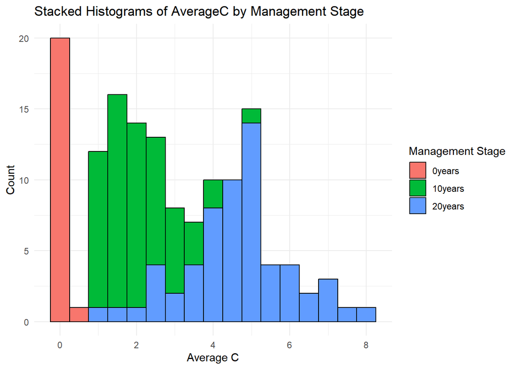

```r
# Stacked histograms for AverageC
ggplot(diversity, aes(x = AverageC, fill = as.factor(ManagementStage))) +
  geom_histogram(position = "stack", binwidth = 0.5, color = "black") +
  labs(
    title = "Stacked Histograms of AverageC by Management Stage",
    x = "Average C",
    y = "Count",
    fill = "Management Stage"
  ) +
  theme_minimal()
```

```r
means_table <- diversity %>%
  group_by(ManagementStage) %>%
  summarise(
    mean_SpeciesRichness = mean(SpeciesRichness),
    mean_AverageC = mean(AverageC)
  )

kable(means_table)
```

| ManagementStage | mean_SpeciesRichness | mean_AverageC |
| --- | --- | --- |
| 0years | 1.047619 | 0.0152381 |
| 10years | 6.733333 | 2.0848333 |
| 20years | 7.633333 | 4.6415000 |

The `SpeciesRichness` before restoration efforts is very low, and there is a substantial increase in `SpeciesRichness` after 10years of restoration efforts increases significantly. There is a smaller increase from 10years to 20years, indicating that the rate of increase has slowed, but stays positive nonetheless. This suggests that while new species continue to establish, competitive dynamics and ecological succession might be limiting further dramatic increases in species numbers.

## Computer-intensive methods

```r
# Perform one-sample t-test
one_sample_test <- t.test(data_20years$AvgOverSppC, mu = 1)

print(one_sample_test)
```

```
    One Sample t-test

data:  data_20years$AvgOverSppC
t = 1.8511, df = 59, p-value = 0.06916
alternative hypothesis: true mean is not equal to 1
95 percent confidence interval:
 0.9951815 1.1238185
sample estimates:
mean of x
   1.0595
```

Based on the t-test alone, it seems that we are not yet at the point where `AvgOverSppC` is significantly greater than 1, although the mean is slightly above 1.

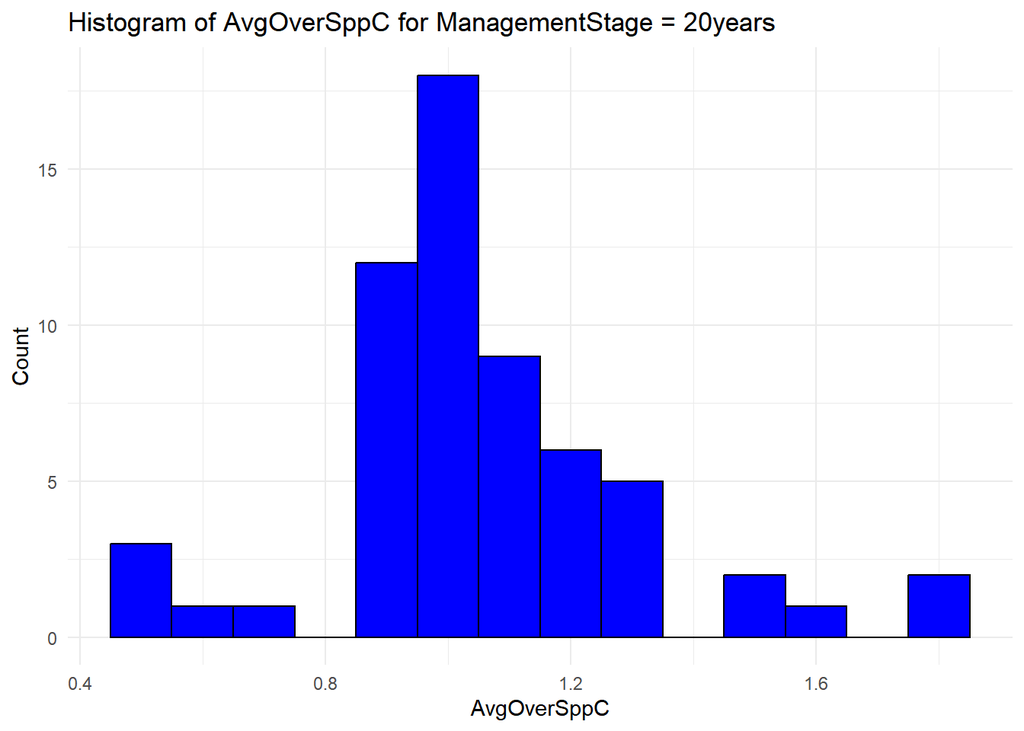

```r
# Histogram of AvgOverSppC
ggplot(data_20years, aes(x = AvgOverSppC)) +
  geom_histogram(binwidth = 0.1, fill = "blue", color = "black") +
  theme_minimal() +
  labs(title = "Histogram of AvgOverSppC for ManagementStage = 20years",
       x = "AvgOverSppC",
       y = "Count")
```

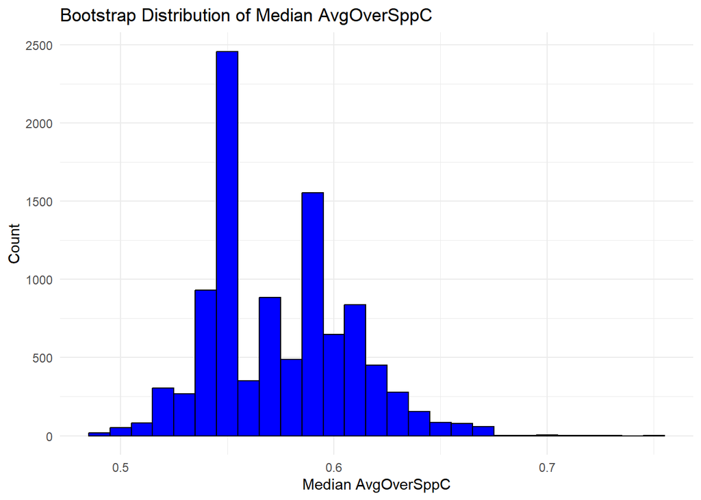

```r
# Function to calculate median AvgOverSppC
bootstrap_median <- function(data, n = 10000) {
  medians <- numeric(n)
  for (i in 1:n) {
    resample <- data[sample(1:nrow(data), replace = TRUE), ]
    resample$AvgOverSppC <- resample$AverageC / resample$SpeciesRichness
    medians[i] <- median(resample$AvgOverSppC, na.rm = TRUE)
  }
  return(medians)
}

# Perform bootstrap
set.seed(05312024)
bootstrap_results <- bootstrap_median(data_20years)

# Plot histogram of bootstrap replicates
ggplot(data.frame(bootstrap_results), aes(x = bootstrap_results)) +
  geom_histogram(binwidth = 0.01, fill = "blue", color = "black") +
  theme_minimal() +
  labs(title = "Bootstrap Distribution of Median AvgOverSppC",
       x = "Median AvgOverSppC",
       y = "Count")
```

```r
# Calculate mean, median, and 95% CI
boot_mean <- mean(bootstrap_results)
boot_median <- median(bootstrap_results)
boot_ci <- quantile(bootstrap_results, c(0.025, 0.975))

results <- data.frame(
  Statistic = c("Bootstrapped Mean", "Bootstrapped Median", "95% CI Lower", "95% CI Upper"),
  Value = c(boot_mean, boot_median, boot_ci[1], boot_ci[2])
)

kable(results)
```

| Statistic | Value |
| --- | --- |
| Bootstrapped Mean | 0.5747049 |
| Bootstrapped Median | 0.5712500 |
| 95% CI Lower | 0.5190000 |
| 95% CI Upper | 0.6366667 |

## Correlation

```r
# Calculate correlation
cor_results <- cor.test(diversity$TotalCover, diversity$SpeciesRichness)

# Correlation results
correlation_results <- data.frame(
  Statistic = c("t-value", "Degrees of Freedom (df)", "P-value", "95% CI Lower", "95% CI Upper", "Correlation Coefficient"),
  Value = c(10.307, 139, "< 2.2e-16", 0.5530542, 0.7426924, 0.6581903)
)

# Create HTML table
kable(correlation_results, format = "html", table.attr = "style='width:50%;'", caption = "Pearson's Product-Moment Correlation Results")
```

Pearson's Product-Moment Correlation Results

| Statistic | Value |
| --- | --- |
| t-value | 10.307 |
| Degrees of Freedom (df) | 139 |
| P-value | < 2.2e-16 |
| 95% CI Lower | 0.5530542 |
| 95% CI Upper | 0.7426924 |
| Correlation Coefficient | 0.6581903 |

###### Check Assumptions: Linearity

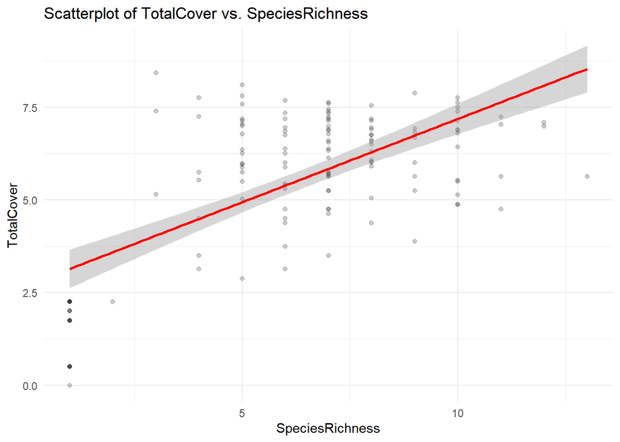

```r
# Scatterplot of TotalCover vs. SpeciesRichness

ggplot(diversity, aes(x = SpeciesRichness, y = TotalCover)) +
  geom_point(alpha = 0.2) +
  geom_smooth(method = "lm", col = "red") +
  theme_minimal() +
  labs(title = "Scatterplot of TotalCover vs. SpeciesRichness",
       x = "SpeciesRichness",
       y = "TotalCover")
```

###### Check Assumptions: Normality

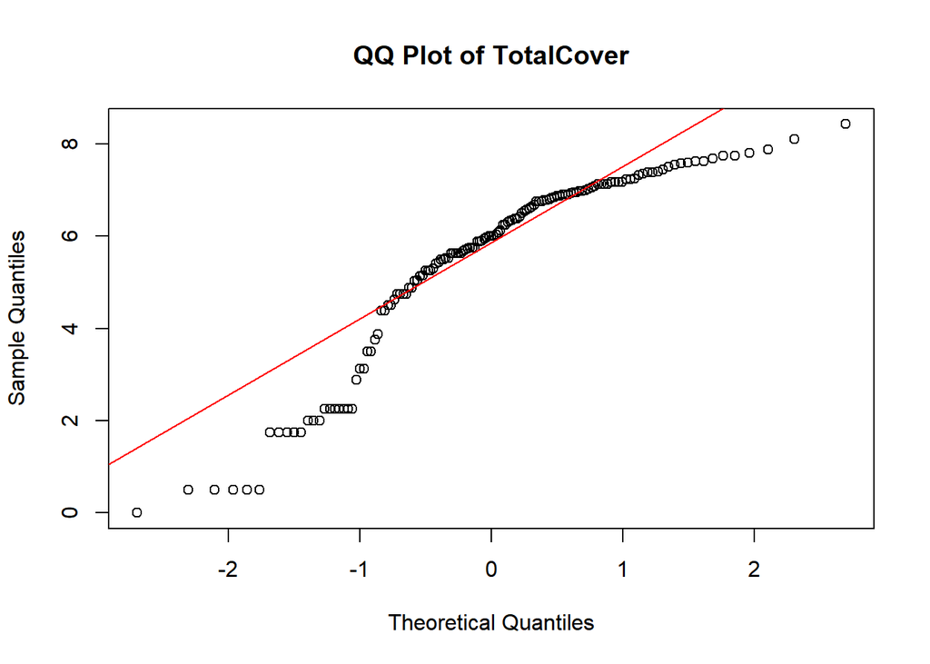

```r
# QQ plots for TotalCover and SpeciesRichness
qqnorm(diversity$TotalCover, main = "QQ Plot of TotalCover")
qqline(diversity$TotalCover, col = "red")
```

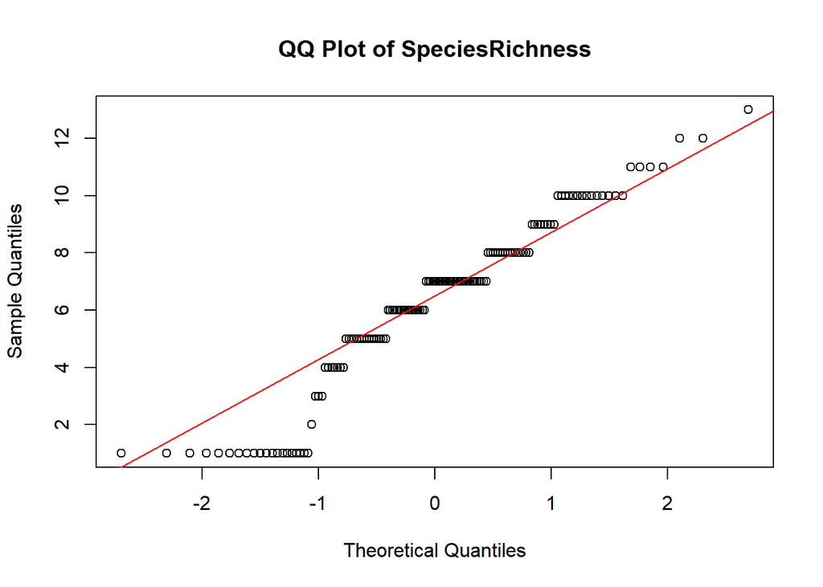

```r
qqnorm(diversity$SpeciesRichness, main = "QQ Plot of SpeciesRichness")
qqline(diversity$SpeciesRichness, col = "red")
```

###### Spearman Rank Correlation

```r
# Perform Spearman rank correlation
spearman_test <- cor.test(diversity$TotalCover, diversity$SpeciesRichness, method = "spearman")

# Extract Spearman's rho
spearman_rho <- spearman_test$estimate

# Add Spearman's rho to the results table
spearman_results <- data.frame(
  Statistic = c("Spearman's rho"),
  Value = c(spearman_rho)
)

# Combine Pearson and Spearman results
combined_results <- rbind(correlation_results, spearman_results)

# Create HTML table
kable(combined_results, format = "html", table.attr = "style='width:50%;'", caption = "Correlation Results for TotalCover and SpeciesRichness")
```

Correlation Results for TotalCover and SpeciesRichness

|  | Statistic | Value |
| --- | --- | --- |
| 1 | t-value | 10.307 |
| 2 | Degrees of Freedom (df) | 139 |
| 3 | P-value | < 2.2e-16 |
| 4 | 95% CI Lower | 0.5530542 |
| 5 | 95% CI Upper | 0.7426924 |
| 6 | Correlation Coefficient | 0.6581903 |
| rho | Spearman's rho | 0.424843955006842 |

###### Interpretation

There is a strong positive correlation between `TotalCover` and `SpeciesRichness`, supporting Tilman’s hypothesis that greater species diversity promotes greater productivity. The Spearman’s correlation also indicates a positive correlation, although it is weaker than Pearson’s correlation. While the relationship is positive, it might not be perfectly linear, which can be seen in the scatterplot.

## Regression

```r
# Linear regression of TotalCover on SpeciesRichness
linear_model <- lm(TotalCover ~ SpeciesRichness, data = diversity)
summary(linear_model)
```

```
Call:
lm(formula = TotalCover ~ SpeciesRichness, data = diversity)

Residuals:
    Min      1Q  Median      3Q     Max
-3.1398 -1.0860  0.0121  1.0427  4.3914

Coefficients:
                Estimate Std. Error t value Pr(>|t|)
(Intercept)       2.6905     0.3013    8.93 2.27e-15 ***
SpeciesRichness   0.4494     0.0436   10.31  < 2e-16 ***
---
Signif. codes:  0 '***' 0.001 '**' 0.01 '*' 0.05 '.' 0.1 ' ' 1

Residual standard error: 1.505 on 139 degrees of freedom
Multiple R-squared:  0.4332,    Adjusted R-squared:  0.4291
F-statistic: 106.2 on 1 and 139 DF,  p-value: < 2.2e-16
```

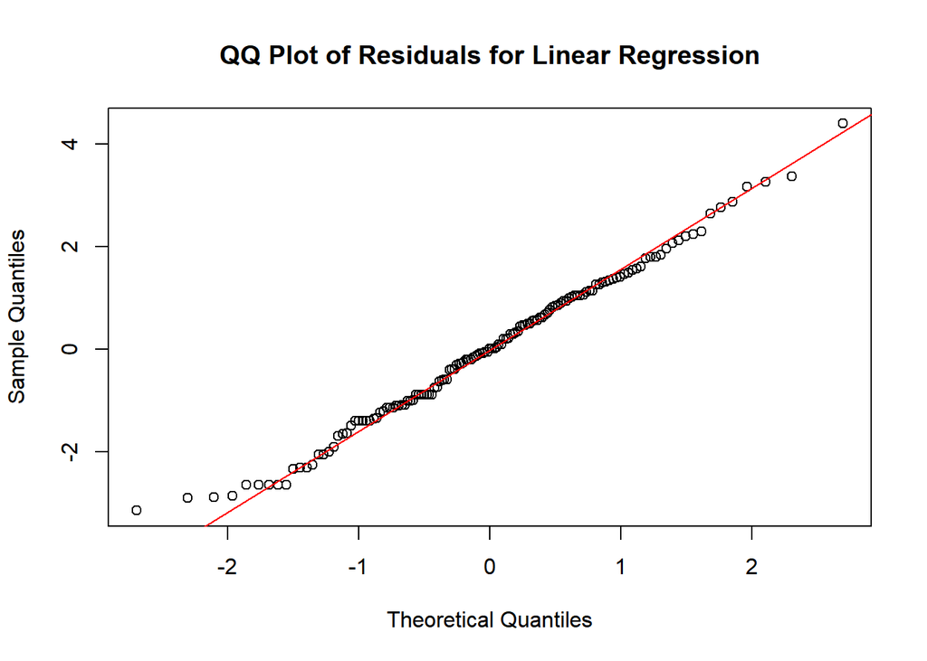

```r
# QQ-plot of the regression residuals
qqnorm(residuals(linear_model), main = "QQ Plot of Residuals for Linear Regression")
qqline(residuals(linear_model), col = "red")
```

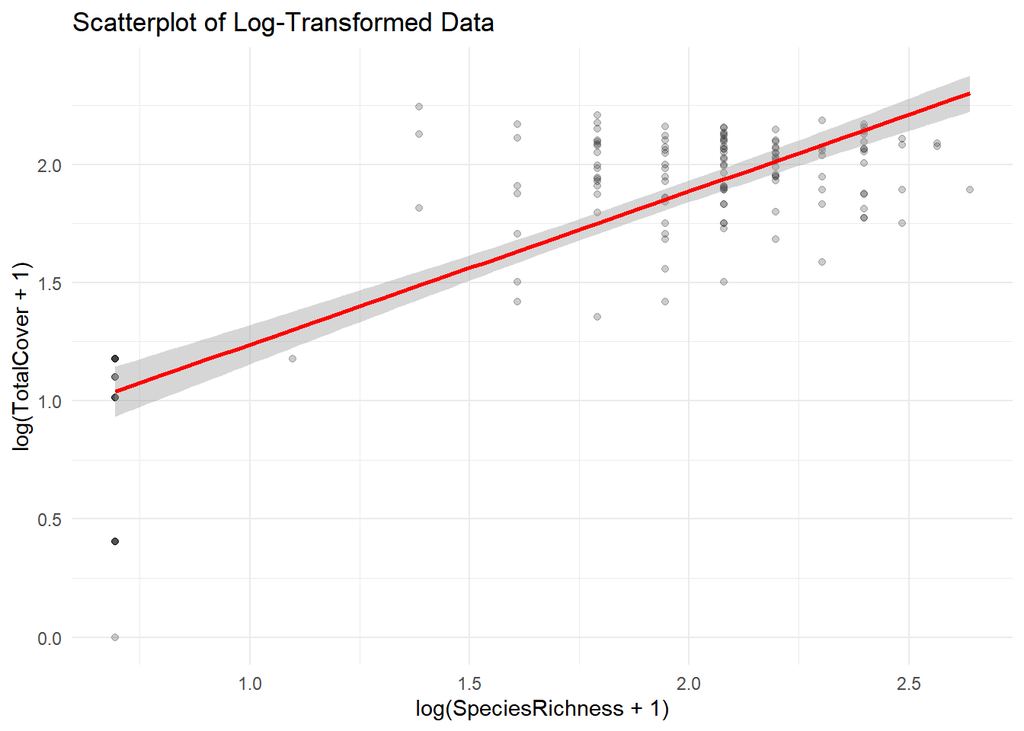

```r
# Log-transform the data
diversity$log_TotalCover <- log(diversity$TotalCover + 1)
diversity$log_SpeciesRichness <- log(diversity$SpeciesRichness + 1)

# Scatterplot of log-transformed data
ggplot(diversity, aes(x = log_SpeciesRichness, y = log_TotalCover)) +
  geom_point(alpha = 0.2) +
  geom_smooth(method = "lm", col = "red") +
  theme_minimal() +
  labs(title = "Scatterplot of Log-Transformed Data",
       x = "log(SpeciesRichness + 1)",
       y = "log(TotalCover + 1)")
```

The data appears more grouped and slightly more linear as compared to the original plot.

```r
# Linear regression of log-transformed data
log_linear_model <- lm(log_TotalCover ~ log_SpeciesRichness, data = diversity)
summary(log_linear_model)
```

```
Call:
lm(formula = log_TotalCover ~ log_SpeciesRichness, data = diversity)

Residuals:
     Min       1Q   Median       3Q      Max
-1.03857 -0.11675  0.01205  0.14820  0.75605

Coefficients:
                    Estimate Std. Error t value Pr(>|t|)
(Intercept)          0.58929    0.08004   7.363 1.44e-11 ***
log_SpeciesRichness  0.64817    0.04118  15.740  < 2e-16 ***
---
Signif. codes:  0 '***' 0.001 '**' 0.01 '*' 0.05 '.' 0.1 ' ' 1

Residual standard error: 0.2645 on 139 degrees of freedom
Multiple R-squared:  0.6406,    Adjusted R-squared:  0.638
F-statistic: 247.7 on 1 and 139 DF,  p-value: < 2.2e-16
```

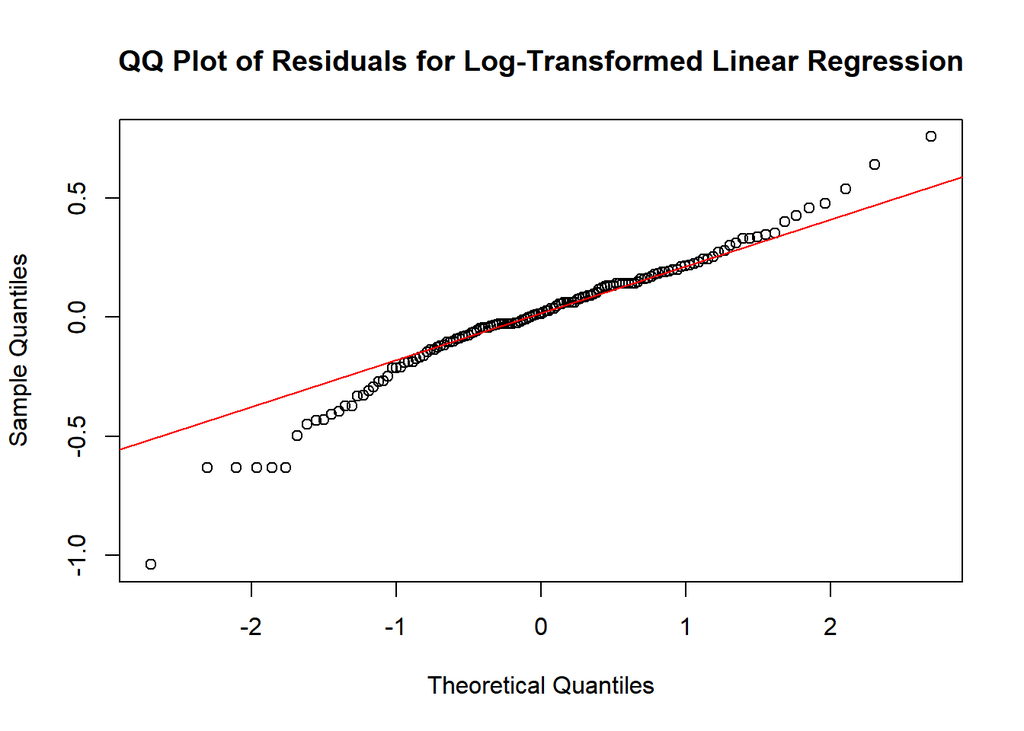

```r
# QQ-plot of the regression residuals for log-transformed data
qqnorm(residuals(log_linear_model), main = "QQ Plot of Residuals for Log-Transformed Linear Regression")
qqline(residuals(log_linear_model), col = "red")
```

```r
# Extract regression equation and R²
log_intercept <- coef(log_linear_model)[1]
log_slope <- coef(log_linear_model)[2]
log_r_squared <- summary(log_linear_model)$r.squared

regression_eq <- paste("log(TotalCover + 1) =", round(log_intercept, 4), "+", round(log_slope, 4), "* log(SpeciesRichness + 1)")
regression_r_squared <- paste("R² =", round(log_r_squared, 4))

# Table the regression equation and R²
regression_results <- data.frame(
  Statistic = c("Regression Equation", "R²"),
  Value = c(regression_eq, regression_r_squared)
)

print(regression_results)
```

```
            Statistic
1 Regression Equation
2                  R²
                                                             Value
1 log(TotalCover + 1) = 0.5893 + 0.6482 * log(SpeciesRichness + 1)
2                                                      R² = 0.6406
```

```r
# ANOVA results for the log-transformed linear regression
anova_results <- anova(log_linear_model)
print(anova_results)
```

```
Analysis of Variance Table

Response: log_TotalCover
                     Df  Sum Sq Mean Sq F value    Pr(>F)
log_SpeciesRichness   1 17.3254 17.3254  247.74 < 2.2e-16 ***
Residuals           139  9.7208  0.0699
---
Signif. codes:  0 '***' 0.001 '**' 0.01 '*' 0.05 '.' 0.1 ' ' 1
```

The ANOVA results for the log-transformed model indicate a highly significant relationship between the log variables. In conclusion, increased species diversity increases productivity, supporting Tilman’s hypothesis.

## Summary and Conclusions

Analysis of the data provided implies that the local volunteer restoration efforts have yielded a significant effect through species diversity and productivity of the ecosystem over time. This is well demonstrated by the marked increase in SpeciesRichness and TotalCover over time, in particular for all plots with more extensive management stages. The strong positive correlation between species diversity and productivity points to how a more diverse plant community should be promoted for associated benefits, e.g. in soil regeneration and nutrient cycling. Based on the results of the log-transformed regression analysis, the benefits of each additional species on the gradient should be set according to resource exploitation principles in ecology, following the law of diminishing returns. Species composition fluctuations during the early phase are generally related to competitive dynamics and succession, all of which trend toward a more stable and productive ecosystem. Those results emphasize the value of continued volunteer effort in restoration and show real ecological benefits that return management and investment in long-term biodiversity initiatives.